# ML_Activitiy6

Daijiro Yokota

September 19, 2019

# LASSO: Shrinkage / Regularization (Notes)

> **READING:**

> For more on this topic, you’re encouraged to read [ISLR](http://faculty.marshall.usc.edu/gareth-james/ISL/ISLR%20Seventh%20Printing.pdf) Chapter 6.2.

## Discussion

Recall the three 3 main types of model selection algorithms:

1. **Variable selection**  
   Identify a subset of predictors that make the “best” predictive model of $y$.  
   **Methods**: best subset selection, backward stepwise selection, forward stepwise selection  
   **Drawbacks**: gives overly optimistic conclusions about the significance of the remaining predictors.
2. **Shrinkage / regularization**  
   Fit a model with all predictors, but shrink / regularize their coefficients toward or to 0. This penalizes weakly informative predictors & creates sparse models.  
   **Methods**: LASSO, ridge regression
3. **Dimension reduction**  
   Reduce the number of predictors by combining them into a smaller set of new predictors.  
   **Methods**: principal components regression  
   **Drawbacks**: predictors lose some meaning

**Model selection: machine learning vs human learning**

We’ve seen that model selection machine learning techniques help us *focus* the model building process. However, they usually leave us to make a final choice between multiple possible models. For example, recall the backward stepwise selection algorithm for the body fat percentage model:

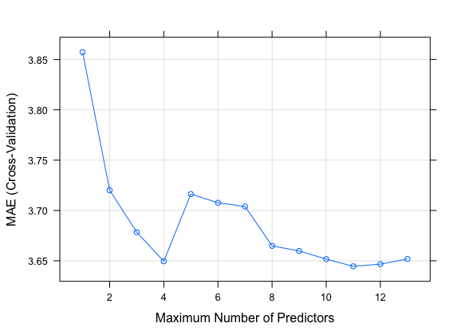

We might logically argue for 4 different models:

- 11 predictor model  
  has the smallest CV MAE (identified by `selectionFunction = "best"`)
- 4 predictor model  
  based on visual cues, this is where the CV MAE starts to plateau / stop improving
- 2 predictor model  
  the simplest model for which the CV MAE isn’t *significantly different* from the “best” 11 predictor model
- 1 predictor model  
  an average prediction error of ~3.85 body fat percentage points might not be practically different than the “best” average prediction error of ~3.65.

When it comes to picking a “final” model, there are some human considerations we must weigh:

- **goal**  
  How will this predictive model be used? Who will use it? Is it important that the model be easy for humans to interpret and apply (in which case we might favor simplicity)? Or is it just going to be utilized by a computer program (in which case we might favor the smallest prediction error)?
- **cost**  
  Data collection and storage require resources (eg: time, computer memory, and money). If these costs are high we might favor a simpler model.

**EXAMPLE**

In each of the scenarios below, would you pick the “oneSE” or “best” model?

1. A doctor wants to use our predictive model of body fat percentage.
2. Spotify wants to use our Homework 3 algorithm to predict the popularity of new songs.
3. Waze wants to update its algorithm which predicts travel time between 2 locations.
4. A small local non-profit hires us to help them build a predictive model of the donation dollars they’ll receive throughout the year.

> **LASSO: least absolute shrinkage and selection operator**

> Our goal is to build a regression model

> $$y = \hat{\beta}_0 + \hat{\beta}_1 x_1 + \cdots + \hat{\beta}_k x_k + \varepsilon$$

> We can summarize the residuals of each case $i$ and the cumulative “residual sum of squares” (ie. sum of the squared residuals) by:

> $$\begin{split}
> y_i - \hat{y}_i & = y_i - (\hat{\beta}_0 + \hat{\beta}_1x_{i1} + \cdots + \hat{\beta}_px_{ip}) \\
> RSS & = \sum_{i=1}^n (y_i - \hat{y}_i)^2 \\
> \end{split}$$

> **Criterion**

> Identify the model coefficients $\hat{\beta}_1, \hat{\beta}_2, ... \hat{\beta}_p$ that *minimize* the **penalized residual sum of squares**:

> $$RSS + \lambda \sum_{j=1}^p \vert \hat{\beta}_j\vert$$

> **Properties**
> - As $\lambda$ increases, coefficients shrink toward 0. This is called **shrinkage** or **regularization**.
> - Picking tuning parameter $\lambda$ is a goldilocks problem, we donât want it to be too big or too small.
>   - When $\lambda = 0$ (too small), LASSO is equivalent to least squares, thus doesnât simplify the model.
>   - When $\lambda$ is too big it also kicks out useful predictors!
> - When $\lambda$ is just right, LASSO helps build **parsimonious** or **sparse** models which only include the most relevant predictors. These are less prone to *overfitting*.
> - We can use cross-validation to help choose an appropriate $\lambda$.

**EXTRA: Bayesian Interpretation**  
IF you’ve taken Bayesian statistics, we can also write the LASSO as a Bayesian model. Specifically, LASSO estimates are equivalent to the posterior mode estimates of $\beta_j$.

$$\begin{split}
Y_i | \beta_0,...\beta_k & \sim N(\beta_0 + \beta_1X_1 + \cdots + \beta_k X_k, \sigma^2) \\
\beta_j & \sim \text{ Laplace (double-exponential)}(0, f(\lambda)) \\
\sigma^2 & \sim \text{ some prior} \\
\end{split}$$

## caret: LASSO regression

To run the LASSO regression using `caret`, first load the package and set the seed:

```r
library(caret)
set.seed(___)
```

You’ll then need to adapt the following code:

```r
# Define a range of lambda tuning parameters to try
# The following is a starting point, but should be tweaked in each context
lambda_grid <- 10^seq(-3, 1, length = 100)

# Perform LASSO
lasso_model <- train(
    y ~ x,
    data = ___,
    method = "glmnet",
    tuneGrid = data.frame(alpha = 1, lambda = lambda_grid),
    trControl = trainControl(method = "cv", number = ___, selectionFunction = ___),
    metric = "MAE",
    na.action = na.omit
)
```

[output not shown]

**Examining the LASSO under each $\lambda$ tuning parameter**

```r
# Plot coefficients for each LASSO
plot(lasso_model$finalModel, xvar = "lambda", label = TRUE, col = rainbow(20))
# Codebook for which variables the numbers correspond to
rownames(lasso_model$finalModel$beta)

# CV RMSE, R^2, MAE metrics for each LASSO model
lasso_model$results

# Plot metrics for each LASSO model
plot(lasso_model)
```

**Identifying the “best” LASSO model**

The “best” model in the sequence is defined relative to the chosen `selectionFunction` and `metric`.

```r
# Identify which tuning parameter (ie. lambda) is "best"
lasso_model$bestTune

# Obtain the predictors & coefficients of the "best" model
coef(lasso_model$finalModel, lasso_model$bestTune$lambda)

# Obtain the predictors & coefficients of LASSO model w/ different lambda
# The .'s indicate that the coefficient is 0
# Eg: lambda = 1 (roughly)
coef(lasso_model$finalModel, 1)

# Get CV measurements for the "best" model
lasso_model$resample
```

## Exercises

We’ll explore the LASSO algorithm using the `bf` data set we’ve been working with in Unit 2. The goal throughout will be to build a predictive regression model of `BodyFat`.

```r
# Load packages
library(ggplot2)   # for visualization
library(dplyr)     # for wrangling
library(caret)     # for machine learning
```

Import the `bf` data. Recall from the previous activity that `bf` includes 2 variables which are neither the response (`BodyFat`) or a reasonable predictor of the response. Be sure to remove these two variables, `Density` and `HeightFt`, from the data set and store the new, sleek data set as `bf_sub`:

```r
# Load the data
bf <- read.csv("http://www.macalester.edu/~ajohns24/data/bodyfatsub.csv")

# Process the data
bf_sub <- bf %>%
  select(-c(Density, HeightFt))
```

**WARNING:** We’ll be using CV to evaluate models. Since CV randomly splits the data into different folds, there’s randomness behind the exact CV errors we get. The answers in the course manual correspond to R version 3.6.1. If you have not yet updated to 3.6.1, your answers will be slightly different. However, the overall conclusions and spirit of the analysis should be similar.

1. **Review: Least squares model**  
   Let’s start with a familiar model, a *least squares model* of `BodyFat` by all predictors in the data set. Execute this in the `caret` package, simultaneously calculate the 10-fold CV MAE, and interpret the CV MAE:

```r
    # Set the seed
set.seed(253)

    # Run the least squares regression model
ls_model <- train(
BodyFat~.,
data = bf_sub,
method = "lm",
trControl = trainControl(method = "cv", number = 10),
na.action = na.omit
)

    # Summarize the model
summary(ls_model)
```

```
##
## Call:
## lm(formula = .outcome ~ ., data = dat)
##
## Residuals:
##      Min       1Q   Median       3Q      Max
## -10.9900  -3.1244  -0.1674   3.0248   9.8648
##
## Coefficients:
##             Estimate Std. Error t value Pr(>|t|)
## (Intercept)  1.68516   23.37412   0.072 0.942587
## Age          0.07189    0.03217   2.234 0.026389 *
## Weight      -0.01762    0.06714  -0.263 0.793153
## Height      -0.24675    0.19114  -1.291 0.197989
## Neck        -0.38682    0.23486  -1.647 0.100887
## Chest       -0.11919    0.10825  -1.101 0.272004
## Abdomen      0.90452    0.09140   9.897  < 2e-16 ***
## Hip         -0.15878    0.14586  -1.089 0.277446
## Thigh        0.17299    0.14683   1.178 0.239926
## Knee        -0.04580    0.24560  -0.186 0.852230
## Ankle        0.18502    0.21985   0.842 0.400862
## Biceps       0.17968    0.17039   1.054 0.292732
## Forearm      0.27605    0.20692   1.334 0.183454
## Wrist       -1.80162    0.53304  -3.380 0.000848 ***
## ---
## Signif. codes:  0 '***' 0.001 '**' 0.01 '*' 0.05 '.' 0.1 ' ' 1
##
## Residual standard error: 4.255 on 236 degrees of freedom
## Multiple R-squared:  0.7505, Adjusted R-squared:  0.7368
## F-statistic: 54.61 on 13 and 236 DF,  p-value: < 2.2e-16
```

```r
    # Calculate the CV MAE (2 approaches)
ls_model$results
```

```
##   intercept     RMSE  Rsquared      MAE    RMSESD RsquaredSD     MAESD
## 1      TRUE 4.394544 0.7141875 3.658544 0.5542562 0.09778461 0.5582472
```

```r
ls_model$resample %>%
summarize(mean(MAE))
```

```
##   mean(MAE)
## 1  3.658544
```

2. **Run the LASSO**  
   The least squares model of `BodyFat` is complicated and possibly overfit. We might improve the interpretability and predictive accuracy by using only a subset of these predictors. Let’s try the LASSO! For now, set the seed to 253 and run the algorithm with the following specifications:
   - we’d like to evaluate models with respect to their 10-fold CV MAE; and
   - given our doctor client, we’d like to i.d. the *simplest* model for which the CV MAE is within one standard error of the minimum CV MAE.

```r
library("glmnet")
    # Define a range of lambda tuning parameters to try
lambda_grid <- 10^seq(-3, 1, length = 100)

    # Set the seed
set.seed(253)

    # Perform LASSO
lasso_model <- train(
BodyFat~.,
data = bf_sub,
method = "glmnet",
trControl = trainControl(method = "cv", number = 10, selectionFunction = "oneSE"),
tuneGrid = data.frame(alpha=1, lambda=lambda_grid),
metric = "MAE",
na.action = na.omit
)
```

3. **Inspecting the LASSO for specific $\lambda$**
   1. Check out the values in `lambda_grid`. What’s the smallest tuning parameter we’re considering? The largest?

```r
summary(lambda_grid)
```

```
##     Min.  1st Qu.   Median     Mean  3rd Qu.     Max.
##  0.00100  0.01001  0.10011  1.12555  1.00082 10.00000
```

0.001 to 10

```
b. Examine the predictors and corresponding coefficients for the LASSO model which uses $\lambda = 0.001$.  How many predictors remain in this model (ie. have non-0 coefficients)?  How do their coefficients compare to the corresponding variables in the least squares model?
```

```r
coef(lasso_model$finalModel, 0.001)
```

```
## 14 x 1 sparse Matrix of class "dgCMatrix"
##                       1
## (Intercept)  4.69096973
## Age          0.07088422
## Weight      -0.00621607
## Height      -0.27835419
## Neck        -0.37638817
## Chest       -0.11577215
## Abdomen      0.88132021
## Hip         -0.14621590
## Thigh        0.14687976
## Knee        -0.02646360
## Ankle        0.15518468
## Biceps       0.16362880
## Forearm      0.25194124
## Wrist       -1.79738703
```

Coefficients are slightly smaller but all the variables remained.

```
c. Repeat part b for 3 other possible tuning parameters: $\lambda = 0.1$, $\lambda = 1$, $\lambda = 10$.
```

```r
coef(lasso_model$finalModel, 0.15)
```

```
## 14 x 1 sparse Matrix of class "dgCMatrix"
##                        1
## (Intercept) -1.137462570
## Age          0.046617024
## Weight       .
## Height      -0.308969713
## Neck        -0.133249226
## Chest        .
## Abdomen      0.742387831
## Hip          .
## Thigh        0.002287218
## Knee         .
## Ankle        .
## Biceps       0.041022617
## Forearm      0.028207366
## Wrist       -1.422796518
```

```r
coef(lasso_model$finalModel, 1)
```

```
## 14 x 1 sparse Matrix of class "dgCMatrix"
##                       1
## (Intercept) -25.0634164
## Age           .
## Weight        .
## Height       -0.1307015
## Neck          .
## Chest         .
## Abdomen       0.5773710
## Hip           .
## Thigh         .
## Knee          .
## Ankle         .
## Biceps        .
## Forearm       .
## Wrist         .
```

```r
coef(lasso_model$finalModel, 10)
```

```
## 14 x 1 sparse Matrix of class "dgCMatrix"
##                   1
## (Intercept) 19.0316
## Age          .
## Weight       .
## Height       .
## Neck         .
## Chest        .
## Abdomen      .
## Hip          .
## Thigh        .
## Knee         .
## Ankle        .
## Biceps       .
## Forearm      .
## Wrist        .
```

4. **Visualizing LASSO shrinkage across possible $\lambda$**  
   In the previous exercise you examined the LASSO model under just 4 of the 100 $\lambda$ tuning parameters under consideration in `lambda_grid`. Instead of examining these 1 by 1, let’s *visualize* the coefficients for each of the 100 LASSO models:

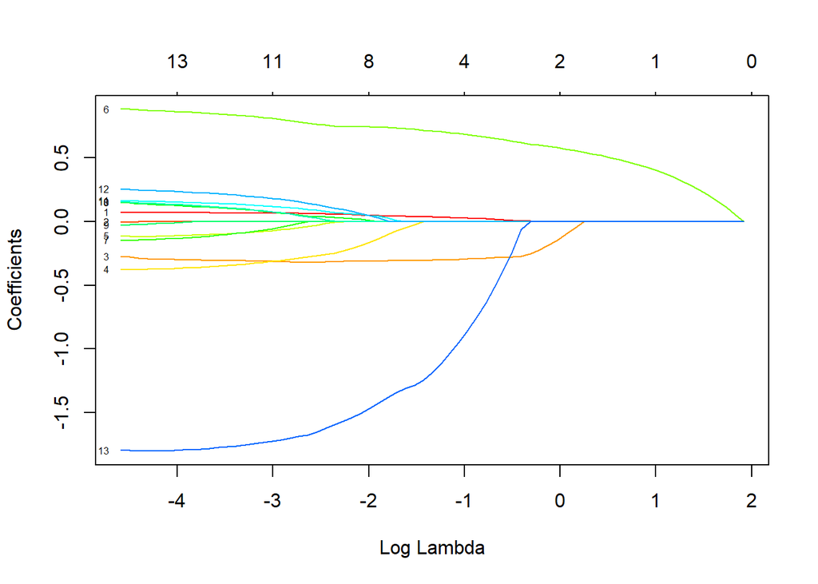

```r
# Plot coefficients for each LASSO
plot(lasso_model$finalModel, xvar = "lambda", label = TRUE, col = rainbow(20))
```

```r
# Codebook for which variables the numbers correspond to
rownames(lasso_model$finalModel$beta)
```

```
##  [1] "Age"     "Weight"  "Height"  "Neck"    "Chest"   "Abdomen" "Hip"
##  [8] "Thigh"   "Knee"    "Ankle"   "Biceps"  "Forearm" "Wrist"
```

There’s a *lot* of information in this plot!

```
- Each **colored line** corresponds to a different predictor.  The small number to the left of each line indicates the predictor by its order in the `rownames()` list.
- The **x-axis** reflects the range of different $\lambda$ values considered in `lasso_model`, reported on the log scale.
- At each $\lambda$, the **y-axis** reflects the predictor coefficients in the corresponding LASSO model.
- At each $\lambda$, the numbers at the **top of the plot** indicate how many predictors remain in the corresponding model.
```

We’ll process this information in the 3 following exercises.

5. **plot: examining coefficients at a specific $\lambda$**  
   Let’s narrow in on specific $\lambda$ values (on the x-axis).
1. Check out the coefficients at the smallest $\lambda$, hence smallest $log(\lambda)$, value on the far left. Confirm that these appear to be roughly equivalent to the least squares coefficient estimates from exercise 1.

Looks like it.

2. Check out the coefficients at $\lambda = 1$ ($log(\lambda) = 0$). Confirm that these are roughly equivalent to the coefficients you calculated in exercise 2.

Yes. Only 2 remained.

6. **plot: examining specific predictors**  
   Let’s narrow in on specific model predictors (lines).
1. What predictor corresponds to the line labeled with the number 13?

“Wrist”

2. Approximate predictor 13’s coefficient for the LASSO model which uses $\lambda \approx 0.37$ ($log(\lambda) \approx -1$).

-1

3. At what $log(\lambda)$ does predictor 13’s coefficient start to drastically shrink?

-3

4. At what $log(\lambda)$ does predictor 13’s coefficient effectively shrink to 0, hence the predictor get dropped from the model?

-0.3

7. **plot: big picture**
1. What aspect of this plot reveals / confirms the LASSO shrinkage phenomenon?

All the coefficients goes to 0 as lambda increases.

2. Which of the 13 original predictors is the most “important” or “persistent” variable, ie. sticks around the longest?

“Abdomen”

3. Which predictor is the least persistent?

4. How many predictors would remain in the model if we used $\lambda \approx 0.135$ ($log(\lambda) = -2$)?

8. **Tuning & picking $\lambda$**  
   In order to pick *which* $\lambda$ (hence LASSO model) is “best”, we can plot and compare the 10-fold CV MAE for each model. Construct both plots below, the second of which zooms in on the first:

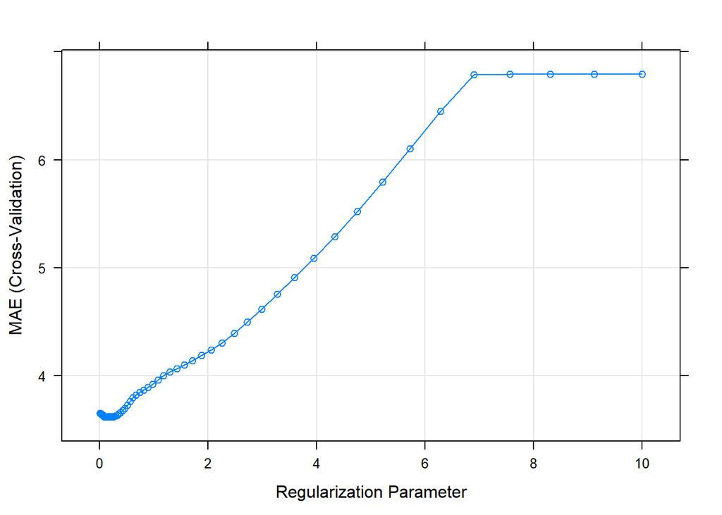

```r
    # Plot metrics for each LASSO model
plot(lasso_model)
```

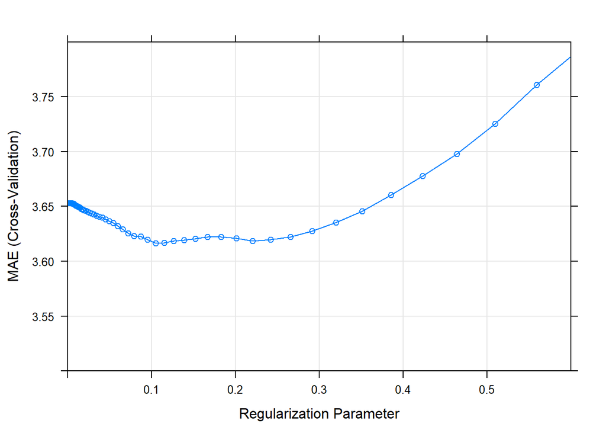

```r
    # ZOOM IN: lot metrics for each LASSO model
plot(lasso_model, xlim = c(0,0.6), ylim = c(3.5, 3.8))
```

In this plot, the x-axis still indicates the $\lambda$ used in each of the 100 LASSO models under consideration (not on the log scale), but now the y-axis shows the 10-fold CV MAE.

1. Using the information from these plot, describe the “goldilocks” problem of selecting $\lambda$: What are the consequences when $\lambda$ is too small? Too large?

If too small, the MAE is basically the same as Least squared. If too big, MAE exceeds the one for Least squared.

2. *Roughly*, which value of the $\lambda$ tuning parameter produces a LASSO model with the best, ie. smallest, CV MAE?

0.11

3. Identify the “best” $\lambda$, that which produces the *simplest* model for which the CV MAE is within one standard error of the minimum CV MAE. (Quickly glance at the results for this $\lambda$ in your plots.)

```r
# Identify which tuning parameter (ie. lambda) is "best"
lasso_model$bestTune
```

```
##    alpha   lambda
## 69     1 0.559081
```

9. **Examining & evaluating the best LASSO model**  
   Let’s focus on the LASSO model which uses the “best” $\lambda$ that you identified in part c. Now that you’ve done the hard work of *building* this model, let’s *examine* and *evaluate* it.
1. Use `coef()` to check out the predictors & corresponding coefficients for this model. Which predictors remain? Are these similar to the predictors that we selected using backward stepwise selection in the previous activity?

```r
coef(lasso_model$finalModel, 0.509)
```

```
## 14 x 1 sparse Matrix of class "dgCMatrix"
##                        1
## (Intercept) -13.12536663
## Age           0.01835802
## Weight        .
## Height       -0.28366191
## Neck          .
## Chest         .
## Abdomen       0.65430490
## Hip           .
## Thigh         .
## Knee          .
## Ankle         .
## Biceps        .
## Forearm       .
## Wrist        -0.49990321
```

Abdomen, Wrist, Height, and Age

We only had Wrist and Abdomen with backward stepwise selection.

2. **Is it wrong?** Do a quick check of the residuals. **NOTE:** The syntax is different than for the `lm()` model.

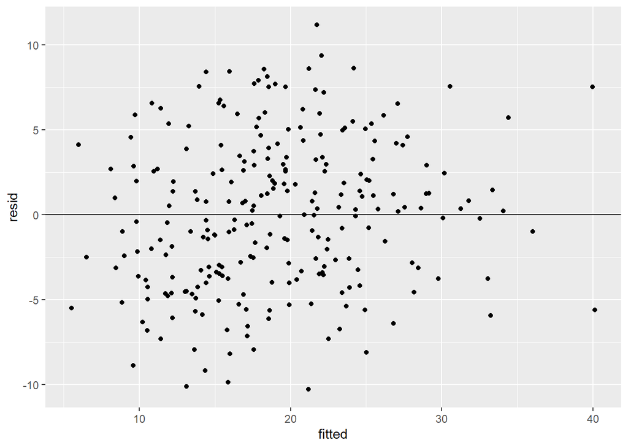

```r
# Combine residuals & predictions into data frame
result_df <- data.frame(resid = resid(lasso_model), fitted = fitted(lasso_model))

# Residual plot
ggplot(result_df, aes(x = fitted, y = resid)) +
  geom_point() +
  geom_hline(yintercept = 0)
```

Residual plot looks okay with the points scattered around the plot.

3. **Is it strong?** Using information from `lasso_model$results` or `lasso_model$resample` approximate the $R^2$ value for your LASSO model.

```r
lasso_model$results %>%
  filter(lambda==lasso_model$bestTune$lambda)
```

```
##   alpha   lambda     RMSE  Rsquared      MAE    RMSESD RsquaredSD
## 1     1 0.559081 4.514558 0.7047897 3.761031 0.4727433 0.08437172
##       MAESD
## 1 0.5011997
```

4. **Does it produce accurate predictions?** Using information from `lasso_model$results` or `lasso_model$resample`, calculate the 10-fold CV MAE for this model. (This provides a rigorous numerical summary of what you observed in the plots.)

10. **Significant?**  
    In STAT 155 we spend a lot of time examining significance & p-values. The LASSO algorithm doesn’t report p-values. Why is this ok / why don’t we need this information anyway?

Because we are removing the variables based on the residual and penalty term.

11. **LASSO vs least squares (and predictions)**
1. With respect to CV MAE, how does the LASSO model performance compare to the least squares model from exercise 1?

2. Use both `lasso_model` and `ls_model` to predict the body fat percentage of the following new patient. `predict()` works the same for both.

```r
new_patient <- data.frame(Age = 50, Weight = 200, Height = 70, Neck = 40, Chest = 115, Abdomen = 105, Hip = 100, Thigh = 60, Knee = 38, Ankle = 23, Biceps = 32, Forearm = 29, Wrist = 19)

predict(ls_model, new_patient)
```

```
##        1
## 26.81807
```

```r
predict(lasso_model, new_patient)
```

```
## [1] 27.08227
```

3. Do the LASSO and least squares model give similar predictions?! Does this calm any fears you might have had about shrinking coefficients?!

They do. Maybe we are underestimating the coefficients by shrinking them.

4. Which final model would you choose, the LASSO or least squares?

Least Squares. I think it’s simple and reasonable to use.

## Digging deeper (optional)

If you finish the exercises above, keep learning! Choose your own adventure below. Learning requires a growth mindset and curiosity – it doesn’t stop with the completion of tasks (eg: the exercises above).

**OPTIONAL EXERCISE 1: PRACTICE ON ANOTHER DATA SET**  
The `Hitters` data in the `ISLR` package contains the salaries and performance measures for 322 Major League Baseball players:

```r
# Load the data
library(ISLR)
data(Hitters)

# IN THE CONSOLE (not in the Rmd): Examine codebook
#?Hitters
```

Use LASSO to determine the “best” predictive model of player `Salary`. If you didn’t already, also use backward stepwise to determine the best predictive model.

**OPTIONAL EXERCISE 2: UNIT REFLECTION**

We find ourselves at the end of Unit 2 on “Regression: Model Building”! Take some time to collect your notes. Some things to think about:

- Can you create a diagram of the different concepts, techniques, & themes we’ve discussed in this unit?
- Would you find it useful to summarize / collect the syntax we’ve used throughout this unit in an “appendix” which you can add to throughout the semester?